# LLMs, Reasoning, and Agentic AI

Karl Ho

# The Big Picture

## Three Layers of Modern AI

[figure not shown]

**Key insight**: We moved from models that **predict text** → models that **think** → systems that **act**.

# Part I: Large Language Models

## The LLM Training Pipeline

[figure not shown]

## Deep Dive: Internet-Scale Data

**What is “Internet-Scale Data”?**

The raw material for pre-training. Models like GPT-4 and Llama 3 train on **trillions of tokens** — a token is roughly ¾ of a word.

| Dataset | Size | Content |
| --- | --- | --- |
| Common Crawl | ~3 T tokens | Web pages (filtered for quality) |
| Books & Papers | ~100 B tokens | Textbooks, journals, Project Gutenberg |
| Code | ~500 B tokens | GitHub, Stack Overflow |
| Wikipedia | ~4 B tokens | Encyclopedic knowledge |
| Curated | varies | Instruction sets, dialogue |

**Key decisions**: Deduplication, toxicity filtering, data mixing ratios — these shape what the model “knows” before training begins.

📖 *Reference*: [Hugging Face LLM Course — Pre-training Data](https://huggingface.co/learn/llm-course)

## Deep Dive: The Transformer Architecture

**What is a Transformer?**

The **neural network architecture** introduced by Vaswani et al. (2017) that replaced RNNs and LSTMs. All modern LLMs are built on it.

[figure not shown]

**Key innovations**: (1) **Parallelism** — unlike RNNs, all positions are computed simultaneously; (2) **Attention** — any token can attend to any other; (3) **Depth** — GPT-4 has ~120 layers, each with attention + FFN.

📖 *Reference*: Vaswani et al. (2017). [Attention Is All You Need](https://arxiv.org/abs/1706.03762). *NeurIPS*.

## Deep Dive: Self-Attention — The Core Formula

**Thought Exercise**

Imagine reading a sentence. For each word, your brain **decides which other words matter most** for understanding it. Self-attention does the same thing — mathematically. “Bank” near “river” means something different from “bank” near “money,” and attention figures this out.

$$\text{Attention}(Q, K, V) = \underbrace{\text{softmax}}_{\substack{\text{normalize to} \\ \text{probabilities}}}\left(\frac{\overbrace{QK^T}^{\text{how relevant is each token?}}}{\underbrace{\sqrt{d_k}}_{\text{prevent gradient vanishing}}}\right)\underbrace{V}_{\text{retrieve content}}$$

[figure not shown]

*↓ Component-by-component breakdown below · → to skip to loss function*

## Component: Q, K, V — The Three Projections

Each input token $x_i$ is **linearly projected** into three vectors:

$$Q_i = x_i W^Q, \qquad K_i = x_i W^K, \qquad V_i = x_i W^V$$

| Component | Analogy | Role |
| --- | --- | --- |
| **Query** ($Q$) | Library patron’s question | “What am I looking for?” |
| **Key** ($K$) | Book index entries | “What do I contain?” |
| **Value** ($V$) | Book content | “What information do I carry?” |

The weight matrices $W^Q, W^K, W^V \in \mathbb{R}^{d_{\text{model}} \times d_k}$ are **learned during training**. Different attention heads learn different projections, capturing syntax in one head, coreference in another, semantic similarity in a third.

📖 *Reference*: [Hugging Face LLM Course — Attention Mechanism](https://huggingface.co/learn/llm-course)

## Component: $QK^T$ — The Attention Score Matrix

The dot product $QK^T$ computes **pairwise relevance** between every pair of tokens:

$$\text{score}(i,j) = Q_i \cdot K_j^T$$

**Visualizing the Score Matrix**

For a sequence of length $n$, $QK^T$ produces an $n \times n$ matrix. Entry $(i,j)$ measures how much token $i$ should attend to token $j$.

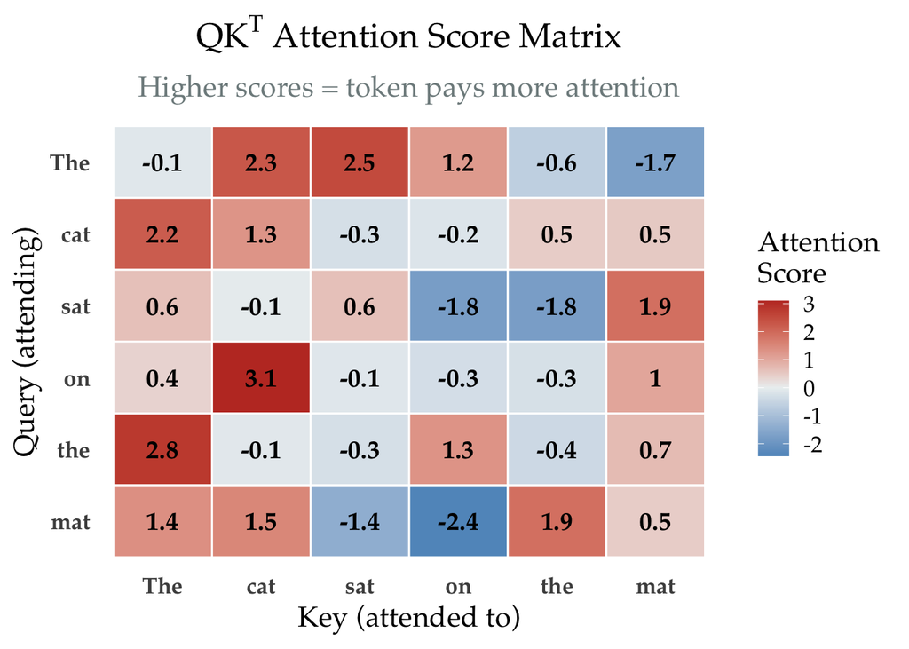

## Component: Scaling by $\sqrt{d_k}$

$$\frac{QK^T}{\sqrt{d_k}}$$

**Why scale?** Without scaling, when $d_k$ is large (e.g., 128), dot products grow in magnitude, pushing softmax into **saturation regions** where gradients vanish:

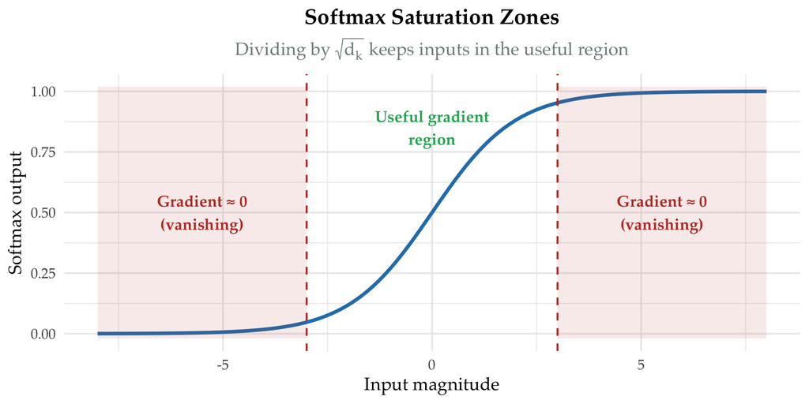

The variance of $QK^T$ entries scales as $O(d_k)$. Dividing by $\sqrt{d_k}$ normalizes it back to unit variance, keeping gradients healthy.

📖 *Reference*: Vaswani et al. (2017), §3.2.1.

## Component: Softmax — From Scores to Probabilities

$$\text{softmax}(z_i) = \frac{e^{z_i}}{\sum_j e^{z_j}}$$

Converts raw scores into a **probability distribution** — attention weights that sum to 1:

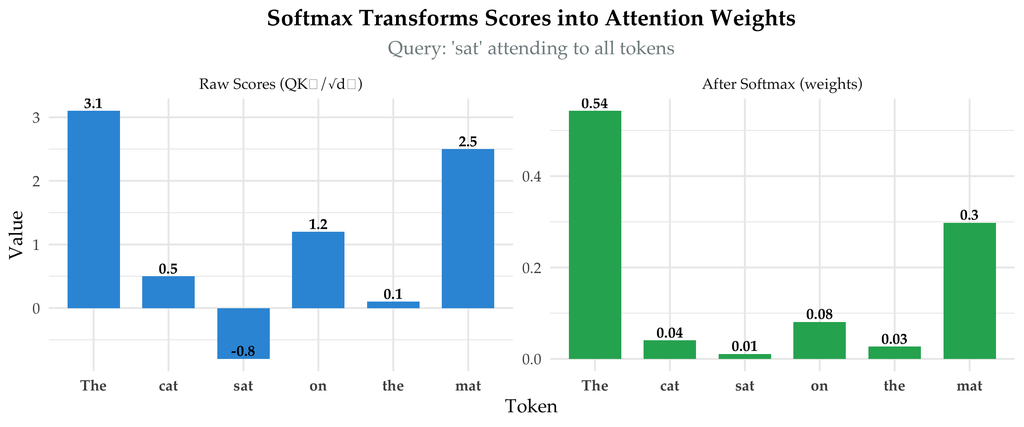

**Data Visualization note**: Side-by-side bar charts show the transformation — raw scores become a proper distribution. The highest-score token “The” dominates after softmax.

## Component: Multiply by V — Retrieving Content

The final step multiplies the attention weights by the **Value** vectors:

$$\text{Output}_i = \sum_j \underbrace{\alpha_{ij}}_{\text{attention weight}} \cdot \underbrace{V_j}_{\text{content of token } j}$$

Each output is a **weighted average** of all value vectors. Tokens receiving high attention contribute more of their content.

**Multi-Head Attention**

In practice, transformers run **multiple attention heads in parallel** (e.g., 32 or 96), each learning different relationships:

- Head 1 may capture **syntactic** dependencies (subject–verb)
- Head 2 may capture **coreference** (pronoun → noun)
- Head 3 may capture **semantic** similarity (synonyms)

Results are concatenated and linearly projected:
$$\text{MultiHead}(Q,K,V) = \text{Concat}(\text{head}_1, \dots, \text{head}_h)W^O$$

📖 *Reference*: [Hugging Face LLM Course — Multi-Head Attention](https://huggingface.co/learn/llm-course)

## Deep Dive: Cross-Entropy Loss

**Thought Exercise**

The loss function measures how **wrong** the model’s guesses are. If you’re playing a fill-in-the-blank game and you guess “cat” but the answer is “dog,” the loss is high. If you guess “dog,” the loss is zero. Training is just playing this game **trillions of times** until the model gets very good at guessing.

The pre-training objective — the **only signal** the model learns from:

$$\boxed{\mathcal{L}(\theta) = -\sum_{t=1}^{T} \log P(x_t | x_{<t}; \theta)}$$

**In plain language**: For every token in the training corpus, how **surprised** is the model by the actual next token? Lower loss = less surprise = better predictions.

*↓ MLE derivation and comparison below · → to skip to KL divergence*

## MLE → Log-Likelihood → Cross-Entropy

**Step 1** — We want parameters $\theta$ that maximize the probability of the training data (MLE):

$$\theta^* = \arg\max_\theta \prod_{t=1}^{T} P(x_t | x_{<t}; \theta)$$

**Step 2** — Take the log (products → sums, numerically stable):

$$\theta^* = \arg\max_\theta \sum_{t=1}^{T} \log P(x_t | x_{<t}; \theta)$$

**Step 3** — Negate it (optimizers minimize, not maximize) → **cross-entropy loss**:

$$\boxed{\mathcal{L}(\theta) = -\sum_{t=1}^{T} \log P(x_t | x_{<t}; \theta)}$$

This is equivalent to minimizing the **KL divergence** between the true data distribution and the model.

## MLE in LLMs vs. MLE in Statistics

**Thought Exercise**

MLE (Maximum Likelihood Estimation) is the same **principle** you learn in statistics: find the parameters that make the observed data most probable. In stats, you might estimate one mean and one standard deviation. In LLMs, you’re estimating **billions** of parameters, and there’s no neat formula — you have to search.

**Why LLM Training Uses MLE But Is Fundamentally Different**

The principle is the same — find parameters that maximize the likelihood of observed data. The practice diverges radically.

| Dimension | MLE in Statistics | MLE in LLMs |
| --- | --- | --- |
| **Parameters** | Fixed, small (e.g., $\mu, \sigma$ for a Gaussian — 2 parameters) | $10^9$ to $10^{12}$ neural network weights |
| **Data model** | i.i.d. samples from a known family: $\prod_{i} f(x_i; \theta)$ | Sequential conditional: $\prod_t P(x_t \mid x_{<t}; \theta)$ |
| **Solution** | Often closed-form: $\hat\mu = \bar{x}$ | Never closed-form — stochastic gradient descent for months |
| **Likelihood surface** | Convex (Gaussian, exponential family) | Highly non-convex, $10^{12}$-dimensional |
| **Asymptotics** | $\hat\theta \xrightarrow{d} \mathcal{N}(\theta_0, I_n^{-1})$ — neat theory | No asymptotic theory — scaling laws are empirical |
| **Uncertainty** | Fisher information → confidence intervals | No built-in uncertainty — the model outputs a point prediction |

## MLE Comparison: Visualized

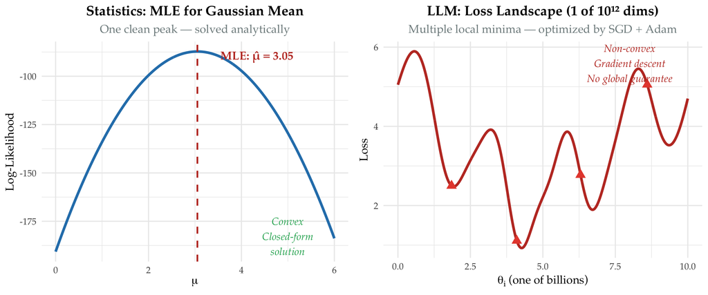

**Data Visualization note**: Side-by-side comparison reveals the fundamental gap — a smooth, convex curve in statistics vs. a rugged landscape in deep learning. Teaching students to **compare distributions visually** is a core data-viz competency.

## Deep Dive: KL Divergence — Theory

**Thought Exercise**

KL divergence measures **how different two probability distributions are**. Think of it as the “distance” between the model’s guesses and reality. If the model thinks “the” follows “of” 80% of the time, but in real text it’s 30%, there’s a big gap. Training shrinks that gap to near zero.

Minimizing cross-entropy is equivalent to minimizing KL divergence:

$$D_{KL}(P_{\text{true}} \| P_{\text{model}}) = \sum_x P_{\text{true}}(x) \log \frac{P_{\text{true}}(x)}{P_{\text{model}}(x)}$$

**Decomposition**:

$$\underbrace{H(P_{\text{true}}, P_{\text{model}})}_{\text{cross-entropy (what we minimize)}} = \underbrace{H(P_{\text{true}})}_{\text{entropy of data (constant)}} + \underbrace{D_{KL}(P_{\text{true}} \| P_{\text{model}})}_{\text{KL divergence (≥ 0)}}$$

So minimizing cross-entropy **is** minimizing KL divergence, because the entropy of the data is fixed.

📖 *Reference*: [Hugging Face LLM Course — Training Objectives](https://huggingface.co/learn/llm-course)

## KL Divergence: Visualizing Distribution Fit

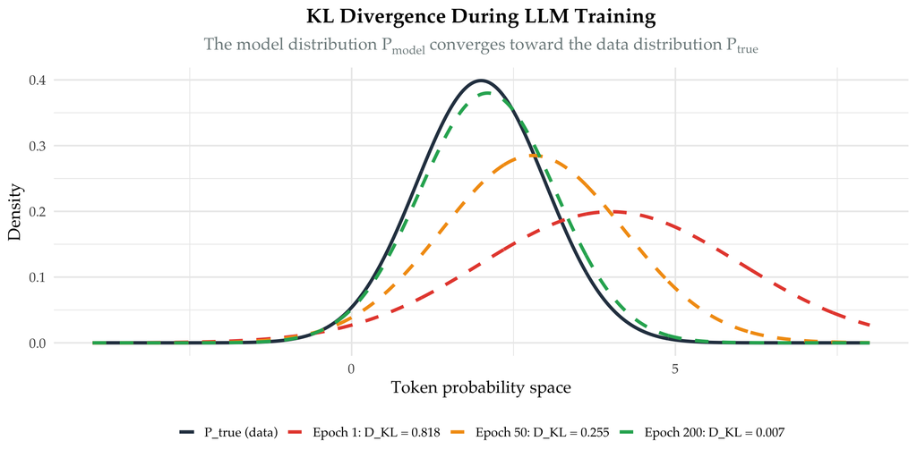

As training progresses, the model’s predicted distribution ($P_{\text{model}}$) converges toward the true data distribution ($P_{\text{true}}$), and $D_{KL} \to 0$.

## KL Divergence: The Area Between Distributions

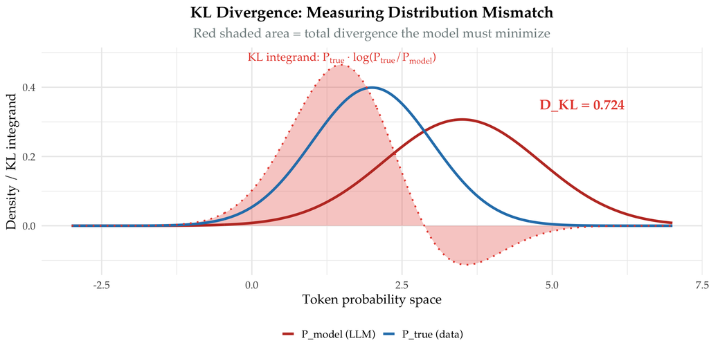

**Key properties of KL divergence**:

- $D_{KL} \geq 0$ always (Gibbs’ inequality)
- $D_{KL} = 0$ iff $P_{\text{model}} = P_{\text{true}}$
- **Asymmetric**: $D_{KL}(P \| Q) \neq D_{KL}(Q \| P)$ — the direction matters

## KL Divergence: Asymmetry Matters

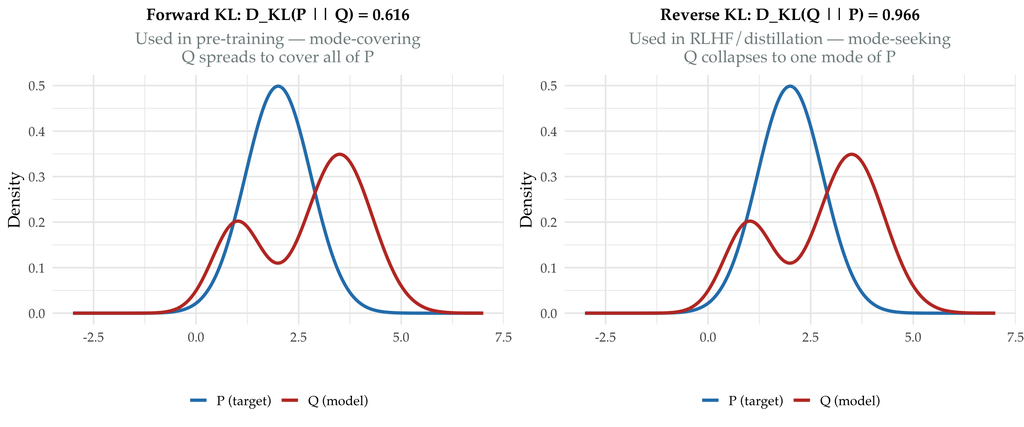

**For LLM training**: Forward KL (pre-training) encourages the model to **cover all modes** of the data distribution — it must assign probability to everything humans write. Reverse KL (RLHF) encourages **mode-seeking** — the model concentrates on the most preferred outputs.

## Deep Dive: SFT — Supervised Fine-Tuning

**What is SFT?**

After pre-training on raw text, the model is fine-tuned on **curated (instruction, response) pairs** to follow human instructions.

| Aspect | Pre-training | SFT |
| --- | --- | --- |
| Data | Raw web text | Human-written (instruction → response) |
| Objective | Predict next token on everything | Predict next token on ideal responses |
| Scale | Trillions of tokens | Thousands–millions of examples |
| Cost | Months, $100M+ | Days, $10K–$1M |
| Result | General knowledge | Instruction-following ability |

**Key insight**: SFT doesn’t teach new knowledge — it teaches the **format** of helpful responses. The knowledge comes from pre-training.

📖 *Reference*: [Hugging Face LLM Course — Fine-tuning](https://huggingface.co/learn/llm-course)

## Deep Dive: RLHF — Human Preference Alignment

**What is RLHF?**

Reinforcement Learning from Human Feedback — training the model to prefer responses that **humans rate as better**, using a learned reward model.

[figure not shown]

**The RLHF objective** includes a KL penalty to prevent the model from diverging too far from the SFT baseline:

$$\max_\theta \; \mathbb{E}_{x \sim D}\big[r_\phi(x, y) - \beta \cdot D_{KL}(\pi_\theta \| \pi_{\text{SFT}})\big]$$

The $\beta$ parameter controls how much the model can deviate — too high, no improvement; too low, reward hacking.

📖 *Reference*: Ouyang et al. (2022). [Training language models to follow instructions with human feedback](https://arxiv.org/abs/2203.02155). *NeurIPS*.

## Deep Dive: The Adam Optimizer

**How does the model actually learn?**

Gradient descent updates parameters to reduce loss. **Adam** (Adaptive Moment Estimation) is the optimizer used by virtually all LLM training.

$$\theta_{t+1} = \theta_t - \frac{\eta}{\sqrt{\hat{v}_t} + \epsilon} \cdot \hat{m}_t$$

| Component | Symbol | Role |
| --- | --- | --- |
| Learning rate | $\eta$ | Step size (~$10^{-4}$) |
| First moment | $\hat{m}_t$ | Exponential moving average of gradients (momentum) |
| Second moment | $\hat{v}_t$ | Exponential moving average of squared gradients (adapts per-parameter) |
| Stability term | $\epsilon$ | Prevents division by zero (~$10^{-8}$) |

**Why Adam over plain SGD?** Each of the $10^{12}$ parameters gets its own effective learning rate — parameters with consistently large gradients get smaller steps, those with sparse gradients get larger ones.

📖 *Reference*: Kingma & Ba (2015). [Adam: A Method for Stochastic Optimization](https://arxiv.org/abs/1412.6980). *ICLR*.

## Emergent Capabilities

[figure not shown]

These capabilities are **not explicitly trained** — they emerge from next-token prediction at sufficient scale.

📖 *Reference*: Wei et al. (2022). [Emergent Abilities of Large Language Models](https://arxiv.org/abs/2206.07682). *TMLR*.

## The Limitations: Five Risks

[figure not shown]

# Part II: Reasoning Models

## System 1 → System 2 Thinking

[figure not shown]

**The key formula** — Performance depends on *both* training and inference compute:

$$\text{Performance} \propto \underbrace{f(\text{Training Compute})}_{\text{more params, data}} + \underbrace{g(\text{Inference Compute})}_{\text{longer "thinking" at test time}}$$

📖 *Reference*: Kaplan et al. (2020). [Scaling Laws for Neural Language Models](https://arxiv.org/abs/2001.08361).

## DeepSeek R1: The GRPO Algorithm

**Thought Exercise**

Imagine giving a student 10 attempts at a math problem, scoring each, then telling them: “do more of what worked, less of what didn’t.” That’s GRPO — no teacher shows the solution; the model discovers reasoning strategies by **trial and error** at scale.

Reasoning can emerge from **pure reinforcement learning** — no human demonstrations needed:

$$\mathcal{L}_{\text{GRPO}} = -\mathbb{E}_{x}\left[\frac{1}{G}\sum_{i=1}^{G} \underbrace{A_i}_{\substack{\text{how much} \\ \text{better than} \\ \text{average?}}} \cdot \underbrace{\log \pi_\theta(y_i | x)}_{\substack{\text{log-prob of} \\ \text{response } y_i}}\right]$$

Where the **advantage** is purely outcome-based:

$$A_i = \frac{r_i - \text{mean}(r_1, \dots, r_G)}{\text{std}(r_1, \dots, r_G)} \qquad r_i = \begin{cases} 1 & \text{correct answer} \\ 0 & \text{incorrect} \end{cases}$$

**What emerged without being programmed**: self-verification, reflection, backtracking, dynamic strategy switching — the “aha moment” ([Guo et al. 2025, *Nature*](https://www.nature.com/articles/s41586-025-09422-z)).

# Part III: Agentic AI

## The ReAct Loop

**Thought Exercise**

A chatbot answers and stops. An **agent** thinks, takes an action (searches the web, runs code, calls an API), looks at the result, and decides whether to keep going. It’s the difference between answering a question and **solving a problem**.

The dominant architecture for AI agents — interleaving **Re**asoning and **Act**ion:

[figure not shown]

Real examples: **Claude Code** (autonomous coding), **Deep Research** (multi-source synthesis), **Codex** (plan → code → test → fix loops).

📖 *Reference*: Yao et al. (2023). [ReAct: Synergizing Reasoning and Acting in Language Models](https://arxiv.org/pdf/2210.03629). *ICLR*.

## Agents vs. Chatbots: The Architecture

[figure not shown]

# Questions & Answers

## Question 1: The Loss Function

**❓ Question**

The cross-entropy loss treats every token prediction equally. Should the word “**the**” carry the same loss weight as the word “**plutonium**”? What would happen if we weighted tokens differently?

**✅ Answer**

**Current practice**: Equal weighting. The model learns that “the” is highly predictable (low loss) and “plutonium” is context-dependent (high loss) — so rare/informative tokens already contribute more to learning through higher per-token loss.

**If we weighted explicitly**: Upweighting factual tokens could improve factual accuracy but might degrade fluency. Some recent work on “selective language modeling” ([Lin et al., 2024](https://arxiv.org/abs/2404.07306)) does exactly this — training only on informative tokens — and shows promising results.

**The tradeoff**: Fluency vs. factuality. Current LLMs are fluent-first; future models may explicitly prioritize accuracy.

## Question 2: KL Divergence in Practice

**❓ Question**

We showed that forward KL is mode-covering and reverse KL is mode-seeking. Why does RLHF use **reverse** KL as its regularizer? What happens if it uses forward KL instead?

**✅ Answer**

**Why reverse KL**: RLHF wants the fine-tuned model to stay **close to the SFT model** without assigning probability to outputs the SFT model considers implausible. Reverse KL ($D_{KL}(\pi_\theta \| \pi_{\text{SFT}})$) penalizes the policy for placing mass where the SFT model has low density — it “mode-seeks” within what the base model already considers reasonable.

**If forward KL instead**: The policy would be forced to **cover all modes** of the SFT model, including low-quality responses the reward model would penalize. This leads to a tension between the reward objective (maximize quality) and the KL constraint (cover everything) — training becomes unstable.

**The deeper insight**: The direction of KL divergence encodes a **philosophical choice** about what errors to tolerate — false positives (generating bad text) vs. false negatives (missing good text).

## Question 3: Reasoning vs. Pattern-Matching

**❓ Question**

The “Illusion of Thinking” paper (Apple ML Research, 2025) suggests reasoning models may not truly reason. If that’s true, does it matter — as long as they get the right answer?

**✅ Answer**

**The pragmatist view**: If the output is reliable, the mechanism doesn’t matter. Engineering cares about results.

**The scientist’s view**: If the mechanism is pattern-matching rather than genuine inference, then:

- Performance will **fail unpredictably** on out-of-distribution problems
- We cannot trust **extrapolation** to novel scenarios
- **Alignment** becomes harder — we can’t align a process we don’t understand

**The research implication**: For knowledge mining, this means always validating LLM-generated analysis against ground truth, especially when the analysis involves novel reasoning rather than retrieval of known patterns.

📖 *Reference*: Apple ML Research (2025). [The Illusion of Thinking](https://arxiv.org/abs/2506.06941).

# Exercise

## Hands-On: Trace the Attention (~3 min)

Given the sentence: **“The Federal Reserve raised interest rates because inflation remained high.”**

**Task**: For the word **“rates”**, rank which other words should receive the **highest attention scores** and explain why.

| Rank | Word | Why? |
| --- | --- | --- |
| 1 | ? | ? |
| 2 | ? | ? |
| 3 | ? | ? |

**Discussion**

**Expected high-attention targets**:

1. **“interest”** — directly modifies “rates” (syntactic dependency)
2. **“raised”** — “rates” is the object being acted upon (semantic role)
3. **“Reserve”** — the actor performing the raising (coreference)
4. **“inflation”** — the causal reason for the rate change (long-range dependency)

**Key point**: Self-attention captures all four relationship types **simultaneously** — syntax, semantics, coreference, and causation — which is why transformers outperform sequential models that process one token at a time.

## Hands-On: Spot the Hallucination (~2 min)

An LLM was asked: *“What is the unemployment rate in the EU in 2025?”*

It responded:

> According to Eurostat (2025), the EU-27 unemployment rate stood at 5.8% in Q2 2025, down from 6.1% in Q2 2024. The largest decline was observed in Spain (–0.9pp) and Greece (–0.7pp), while Germany saw a modest increase (+0.2pp) due to its manufacturing slowdown.

**Task**: What elements of this response should a researcher **verify before citing**, and how?

**Discussion**

**Every factual claim needs verification**:

- ✅ Check: Is 5.8% the actual Eurostat figure? → Go to ec.europa.eu/eurostat
- ✅ Check: Was the prior-year figure 6.1%? → Same source
- ✅ Check: Did Spain decline 0.9pp? → Country-level data
- ⚠️ Red flag: The model may have **interpolated** from older data or **fabricated** plausible-sounding numbers
- ⚠️ Red flag: “Manufacturing slowdown” is an interpretation, not data

**Rule**: Never cite an LLM-generated statistic without primary-source verification. The numbers *look* right, which makes hallucination dangerous.

# Takeaways

## Five Things to Remember

[figure not shown]

## The Formula Sheet

The four formulas that define modern AI:

**1. Self-Attention** (Vaswani et al., 2017):
$$\text{Attention}(Q, K, V) = \text{softmax}\!\left(\frac{QK^T}{\sqrt{d_k}}\right)V$$

**2. Cross-Entropy Loss** (Pre-training objective):
$$\mathcal{L} = -\sum_{t=1}^{T} \log P(x_t \mid x_{<t};\, \theta)$$

**3. Test-Time Compute Scaling** (Reasoning models):
$$\text{Performance} \propto f(\text{Train Compute}) + g(\text{Inference Compute})$$

**4. GRPO Objective** (DeepSeek R1):
$$\mathcal{L}_{\text{GRPO}} = -\mathbb{E}_x\!\left[\frac{1}{G}\sum_{i=1}^{G} A_i \cdot \log \pi_\theta(y_i \mid x)\right]$$

**For Your Research**

These four formulas govern how AI systems learn, reason, and improve. Understanding them is essential for critically evaluating AI-generated research outputs.

## References

- Vaswani et al. (2017). [Attention Is All You Need](https://arxiv.org/abs/1706.03762). *NeurIPS*.
- Kingma & Ba (2015). [Adam: A Method for Stochastic Optimization](https://arxiv.org/abs/1412.6980). *ICLR*.
- Kaplan et al. (2020). [Scaling Laws for Neural Language Models](https://arxiv.org/abs/2001.08361). *arXiv*.
- Ouyang et al. (2022). [Training language models to follow instructions with human feedback](https://arxiv.org/abs/2203.02155). *NeurIPS*.
- Wei et al. (2022). [Emergent Abilities of Large Language Models](https://arxiv.org/abs/2206.07682). *TMLR*.
- DeepSeek AI (2025). [DeepSeek-R1: Incentivizing Reasoning Capability in LLMs via Reinforcement Learning](https://www.nature.com/articles/s41586-025-09422-z). *Nature*.
- Yao et al. (2023). [ReAct: Synergizing Reasoning and Acting in Language Models](https://arxiv.org/pdf/2210.03629). *ICLR*.
- Apple ML Research (2025). [The Illusion of Thinking](https://arxiv.org/abs/2506.06941). *arXiv*.
- Lin et al. (2024). [Rho-1: Not All Tokens Are What You Need](https://arxiv.org/abs/2404.07306). *arXiv*.
- Hugging Face. [LLM Course](https://huggingface.co/learn/llm-course). Online.